# Homework04

## Problem set part 1

### 1

1. error = Y - 2- 3X = 9 - 2 - 3*2 = 1
2. residual = Y - $\hat{Y}$ = 9 - (1.9 + 3.1 * 2) = 0.9

### 2

top left: Y = $\beta_0$ + $\beta_1$ X + $\beta_2$ C + $\beta_3$ D + $\epsilon$

top right: Y = $\beta_0$ + $\beta_1$ X

bottom left: Y = $\beta_0$ + $\beta_1$ X

bottom right: Y = $\beta_0$ + $\beta_1$ X

### 3

1. 76.185
2. 19.693
3. 306.553
4. 1256.671 + (-238.853) * 2 = 778.965
5. Yes. T-statistic.

For model 2, t = -238.853/19.693 = -12.13; It is 12.13 standard deviation away from 0; 12.13 > 1.96(95% CI), so it is statistically significant different from 0 at 95% level.

For model 3, t = -251.181/19.28 = -13.03; It is 13.03 standard deviation away from 0; 13.03 > 1.96(95% CI), so it is statistically significant different from 0 at 95% level.

### 4

AnnualHoursWorked = 10.145 + 110.230 Edu + (-1.581) $Edu^2$

1. A one year increase in education would increase annual hour worked by 110.230 + (-1.581) [(educ+1)^2 - educ^2]
2. 110.230 + (-1.581) * (17^2 - 16^2) = 58.057
3. The relationship gets less positive as educ^2 will increase more fast as education gets larger.
4. As Educ^3, educ^4 are inter-correlated to educ and educ^2

### 5

1. Owning a place to live increases working hours by 50.174 hours.

t = 50.174/32.923 = 1.5239 < 1.96

So this coefficient is not statistically significantly different from 0 at 95% level.

2. -923.904 - (-773.412) = -150.492

People with 4 children under 5 works 150.492hours less than people with 3 chidren under 5.

3. From this table alone, we cannot tell whether there’s a statistically significant difference in hours between having 2 children and having 3. If we want to test it, we could use t-statistics but we need the covariance for the two coefficients.

### 6

1. For homeowner, a one unit increase in education increases annual hours worked by 110.073 + (-53.994) = 56.079

For non-homeowner, a one unit increase in education increases annual hours worked by 110.073

2. Being a homeowner has 53.994 less annual hours worked for each unit increase in education, compared to those not being a homeowner.
3. A one-unit increase in education increases annual hours worked by 6.7%
4. a percent change in education increases annual hours worked by 8.323
5. Since the dependent variable is log(hours worked), hours worked must be > 0, so any observation with 0 hours worked is dropped.

### 7

b

### 8

b, c

### 9

For sample selection bias, one could use inverse probability weighting to adjust the demographic proportion in sample to that in population. For example, for under-presented demographic sample, weight it by: population proportion/sample proportion

### 10

a

## Problem set 2

### 1

```r
dengue <- read_csv("/Users/miss_red/Desktop/Duke Phd/Fall 2025/statistics/Statistics_Fall_2025/inclass/dengue.csv")
ols <- glm(NoYes ~ humid + temp, data = dengue, family = binomial)
summary(ols)
```

```
Call:
glm(formula = NoYes ~ humid + temp, family = binomial, data = dengue)

Coefficients:
            Estimate Std. Error z value Pr(>|z|)
(Intercept) -6.59219    0.30290 -21.764   <2e-16 ***
humid        0.30474    0.01985  15.350   <2e-16 ***
temp         0.03987    0.01933   2.063   0.0391 *
---
Signif. codes:  0 '***' 0.001 '**' 0.01 '*' 0.05 '.' 0.1 ' ' 1

(Dispersion parameter for binomial family taken to be 1)

    Null deviance: 2711.7  on 1997  degrees of freedom
Residual deviance: 1357.0  on 1995  degrees of freedom
  (2 observations deleted due to missingness)
AIC: 1363

Number of Fisher Scoring iterations: 6
```

```r
stargazer(ols, type = "text", title = "OLS Regression: Dengue vs. Humidity & Temperature")
```

```
OLS Regression: Dengue vs. Humidity & Temperature
=============================================
                      Dependent variable:
                  ---------------------------
                             NoYes
---------------------------------------------
humid                      0.305***
                            (0.020)

temp                        0.040**
                            (0.019)

Constant                   -6.592***
                            (0.303)

---------------------------------------------
Observations                 1,998
Log Likelihood             -678.519
Akaike Inf. Crit.          1,363.037
=============================================
Note:             *p<0.1; **p<0.05; ***p<0.01
```

### 2

```r
ols2 <- glm(NoYes ~ humid + temp, data = dengue, family = binomial(link = "logit"))
summary(ols2)
```

```
Call:
glm(formula = NoYes ~ humid + temp, family = binomial(link = "logit"),
    data = dengue)

Coefficients:
            Estimate Std. Error z value Pr(>|z|)
(Intercept) -6.59219    0.30290 -21.764   <2e-16 ***
humid        0.30474    0.01985  15.350   <2e-16 ***
temp         0.03987    0.01933   2.063   0.0391 *
---
Signif. codes:  0 '***' 0.001 '**' 0.01 '*' 0.05 '.' 0.1 ' ' 1

(Dispersion parameter for binomial family taken to be 1)

    Null deviance: 2711.7  on 1997  degrees of freedom
Residual deviance: 1357.0  on 1995  degrees of freedom
  (2 observations deleted due to missingness)
AIC: 1363

Number of Fisher Scoring iterations: 6
```

Holding temperature constant, a one-unit increase in humidity increases odds of observing by 35.6%; holding humiditu constant, a one-unit increase in temperature increases odds of observing by 4.1%

### 3

```r
dengueclean <- dengue |>
  drop_na(humid)
ols3 <- lm(humid ~ temp, data = dengueclean)
summary(ols3)
```

```
Call:
lm(formula = humid ~ temp, data = dengueclean)

Residuals:
     Min       1Q   Median       3Q      Max
-14.7416  -1.8751   0.4252   2.5564  13.9461

Coefficients:
            Estimate Std. Error t value Pr(>|t|)
(Intercept)  2.36152    0.21141   11.17   <2e-16 ***
temp         0.77885    0.01052   74.05   <2e-16 ***
---
Signif. codes:  0 '***' 0.001 '**' 0.01 '*' 0.05 '.' 0.1 ' ' 1

Residual standard error: 3.79 on 1996 degrees of freedom
Multiple R-squared:  0.7331,    Adjusted R-squared:  0.733
F-statistic:  5483 on 1 and 1996 DF,  p-value: < 2.2e-16
```

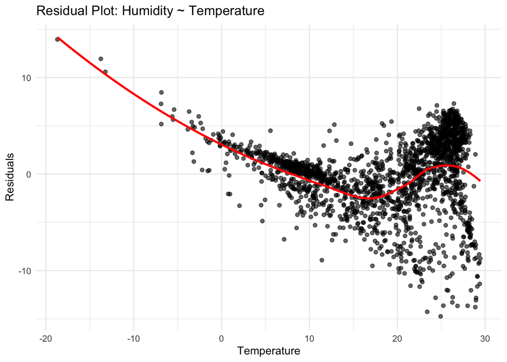

```r
dengueclean$resid <- resid(ols3)

ggplot(dengueclean, aes(x = temp, y = resid)) +
  geom_point(alpha = 0.6) +
  geom_smooth(method = "loess", se = FALSE, color = "red") +
  labs(
    title = "Residual Plot: Humidity ~ Temperature",
    x = "Temperature",
    y = "Residuals"
  ) +
  theme_minimal()
```

```r
robust <- coeftest(ols3, vcov = vcovHC(ols3, type = "HC1"))
summary(robust)
```

```
    Estimate        Std. Error         t value         Pr(>|t|)
 Min.   :0.7788   Min.   :0.01153   Min.   :12.05   Min.   :0.000e+00
 1st Qu.:1.1745   1st Qu.:0.05763   1st Qu.:25.93   1st Qu.:5.967e-33
 Median :1.5702   Median :0.10372   Median :39.81   Median :1.193e-32
 Mean   :1.5702   Mean   :0.10372   Mean   :39.81   Mean   :1.193e-32
 3rd Qu.:1.9659   3rd Qu.:0.14982   3rd Qu.:53.68   3rd Qu.:1.790e-32
 Max.   :2.3615   Max.   :0.19591   Max.   :67.56   Max.   :2.387e-32
```

I think there is heteroskedasticity because for the first model, the residual changes as temperature increases. Besides, standard error of coefficient of temperature in robust is 0.01153, in first model is 0.01052, which means there is some heteroskedasticity error that was adjusted by the robust model.

### 4

```r
dengueclean$log_humid <- log(dengueclean$humid)
model_log <- lm(log_humid ~ temp, data = dengueclean)
coeftest(model_log, vcov = vcovHC(model_log, type = "HC1"))
```

```
t test of coefficients:

              Estimate Std. Error t value  Pr(>|t|)
(Intercept) 1.65904882 0.01821951  91.059 < 2.2e-16 ***
temp        0.05648221 0.00088593  63.755 < 2.2e-16 ***
---
Signif. codes:  0 '***' 0.001 '**' 0.01 '*' 0.05 '.' 0.1 ' ' 1
```

A one-unit increase of temperature increases humidity by 5.648%

### 5

For humidity, when temperature increases from -20 to 0. residual deacrease rapidly, while it keeps relatively less fluctuated around 0 when temperature increases from 0 to 30. So the effect of temperature on humidity is non-linear.